# Untitled

bleh

11/6/2022

### Methods

#### Image Acquisition

Images analyzed in this project were acquired by downloading the R package, rgif, which permits access to the Global Biodiversity Information Facility’s (GBIF) application programming interface. Records from GBIF were now accessible for all Lepidoptera analyzed below.

#### Digitization

Right-wing shapes across ~200 species of Lepidoptera were examined utilizing the image analysis program FIJI. After opening each image, the following sequence was followed depending on scale bar, wing damage, and hindwing exposure. If a scale bar was present, the scale was set in mm. If the right-wing pair was damaged, the image was flipped horizontally. The wings were then traced utilizing the polygon selection tool. A script was created, and the selected points (x and y coordinates) were exported in a .txt file for further analysis.

#### Shape & Comparative Analysis

Outline-based shape analysis, utilizing Elliptical Fourier Analysis (EFA) and Principal Components Analysis (PCA), were performed to compare shape change between species. PCA plot output for both forewing and hindwing can be referenced below (Figures 1 & 2). Evolutionary rates of the PC scores were observed across the Lepidoptera tree (@kawahara2019phylogenomics) and species information was added (Figure 3).

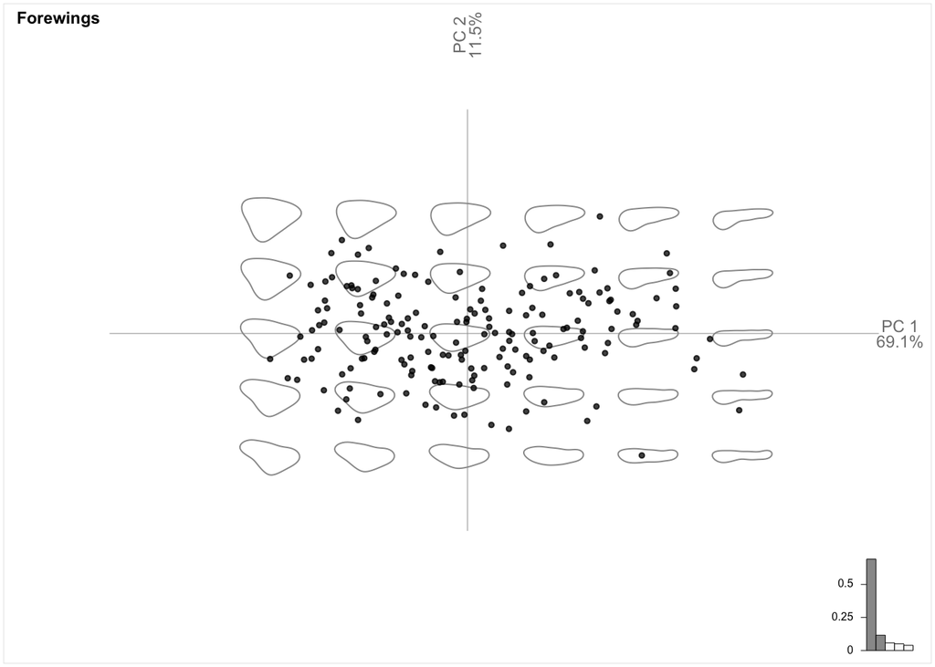

Figure 1: Biplot visualization of PCA 1 and 2 in the forewings

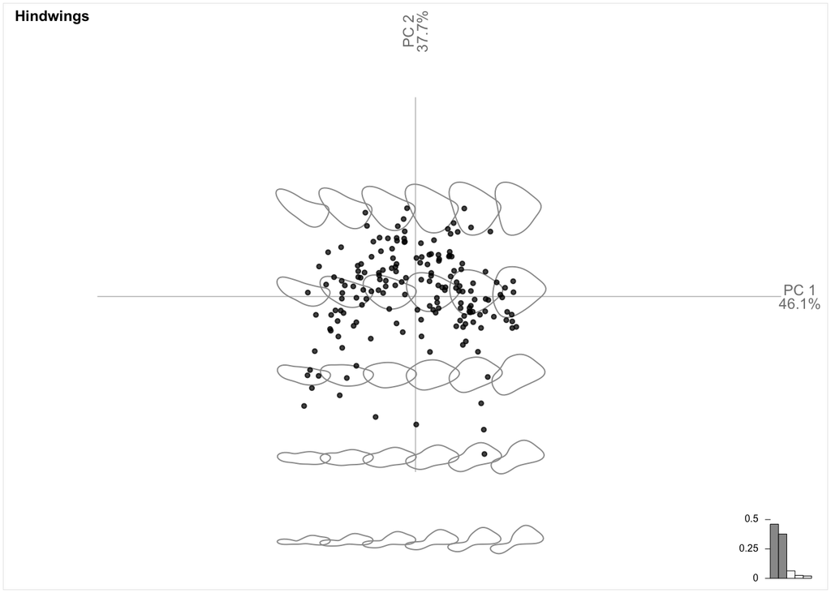

Figure 2: Biplot visualization of PCA 1 and 2 in the hindwings

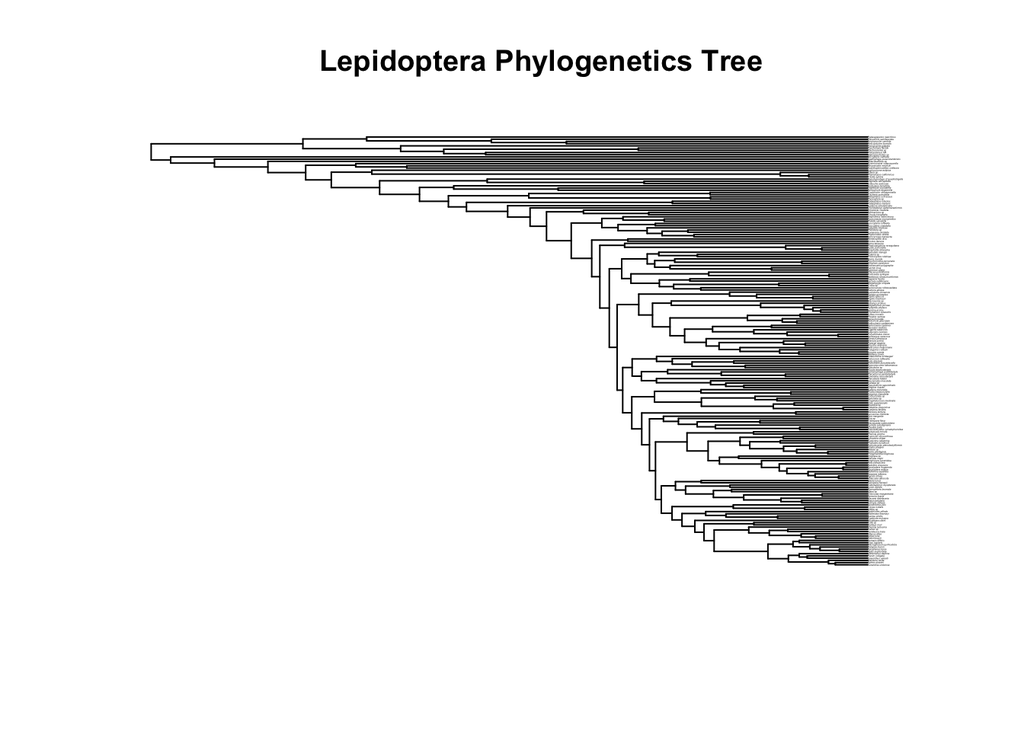

Figure 3: Phylogenetic tree based on @kawahara2019phylogenomics study on Lepidoptera. The same tree is modified to include only species observed in PC analysis and merged with PC data to visualize evolutionary rate shifts

#### Evolutionary Rates & Shifts

The “non-censored test” (@o2006testing) was utilized to estimate the rates of morphological evolution over a phylogenetic tree. Phylogenetic ridge regression (@kratsch2014ridgerace) was then utilized to determine whether the evolutionary shift was to a slower or faster rate. The regressions are based on the phenotype values at each node vs. time between nodes and along the path. The value of the slope parameter of these regressions is the rate.

#### Shape Evolution Correlation

Phylogenetic independent contrasts (PIC) analysis was performed to investigate the correlation in hind and forewing shape evolution. R-squared values were then found by creating a linear model.

### Results

#### Evolutionary Rates: Hindwing vs. Forewing

##### Evolution Rate Estimate of PC1 in Forewing

```
## [1] 0.006478405
```

##### Evolution Rate Estimate of PC2 in Forewing

```
## [1] 0.002334936
```

##### Evolution Rate Estimate of PC1 in Hindwing

```
## [1] 0.01041437
```

##### Evolution Rate Estimate of PC2 in Hindwing

```
## [1] 0.01917866
```

#### Shifts in Evolutionary Rates

##### Hindwing PC1

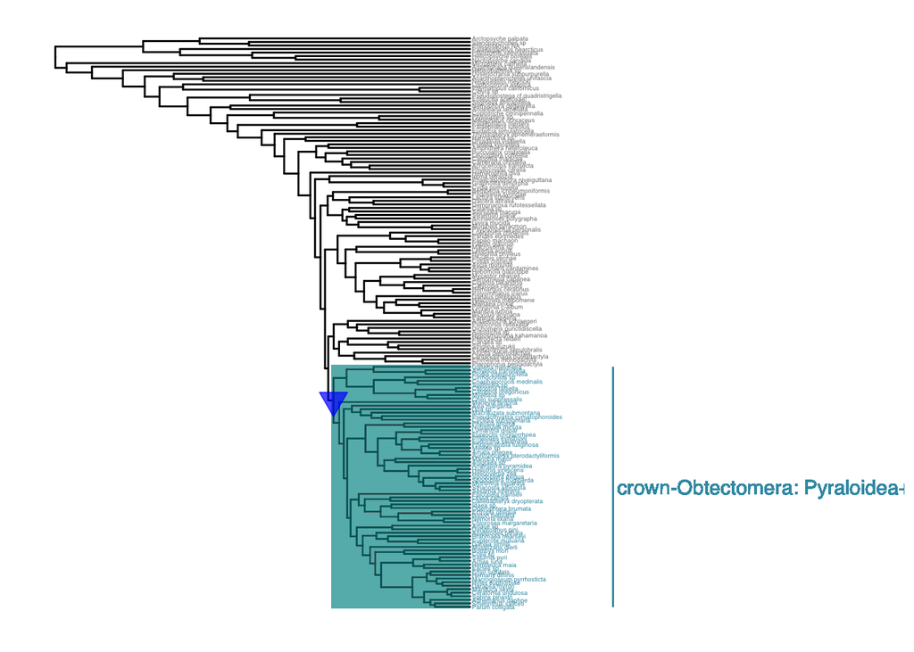

Figure 4: Visualization of evolutionary rate shift in the hindwings’ PC1. Blue and downwards arrow indiactes a significant low rate shift. The table below shows the rate difference compared to the rest of the tree and the significance of the difference

```
## # A tibble: 1 × 4
##       n rate.difference p.value clade
##   <dbl>           <dbl>   <dbl> <chr>
## 1   182        -0.00199   0.001 crown-Obtectomera: Pyraloidea+Mimallonoidea+Dre…
```

##### Hindwing PC2

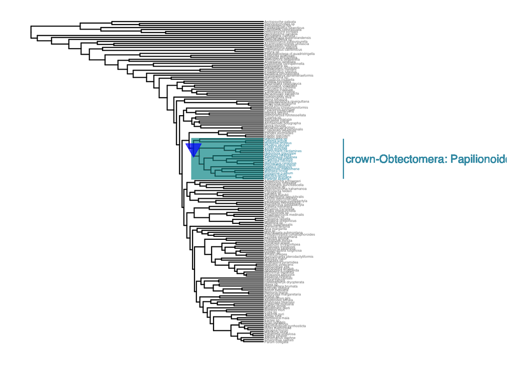

Figure 5: Visualization of evolutionary rate shift in the hindwings’ PC2. Blue and downwards arrow indiactes a significant low rate shift. The table below shows the rate difference compared to the rest of the tree and the significance of the difference

```
## # A tibble: 1 × 4
##       n rate.difference p.value clade
##   <dbl>           <dbl>   <dbl> <chr>
## 1   263        -0.00163   0.001 crown-Obtectomera: Papilionoidea
```

##### Forewing PC1

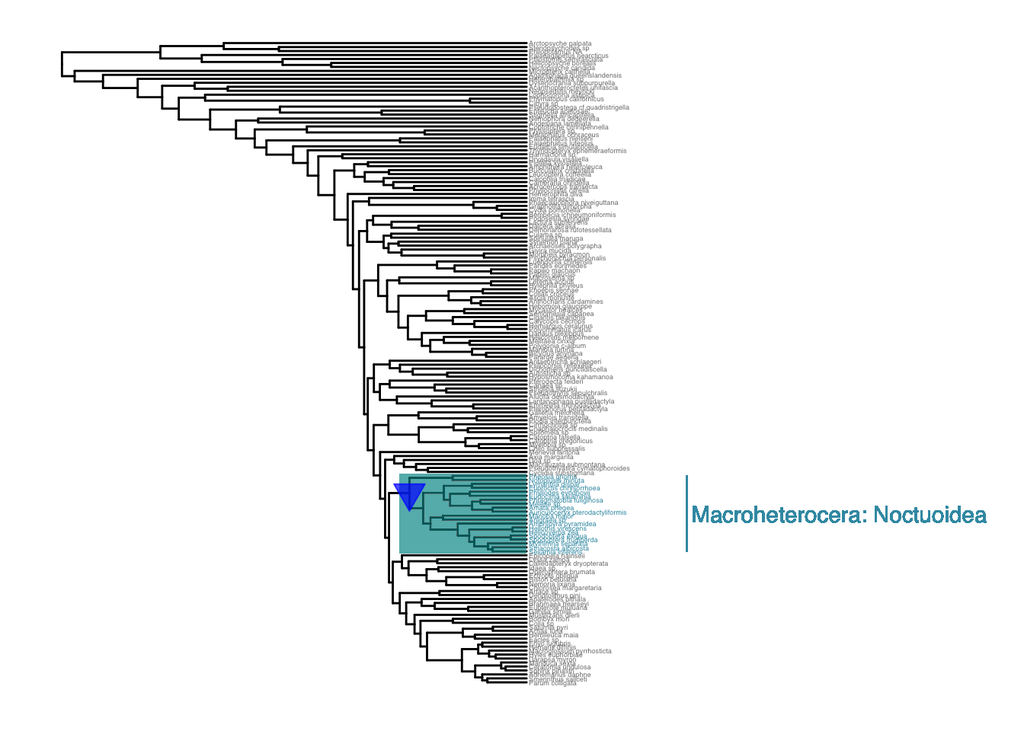

Figure 6: Visualization of evolutionary rate shift in the forewings’ PC1. Blue and downwards arrow indiactes a significant low rate shift. The table below shows the rate difference compared to the rest of the tree and the significance of the difference

```
## # A tibble: 1 × 4
##       n rate.difference p.value clade
##   <dbl>           <dbl>   <dbl> <chr>
## 1   218        -0.00168   0.001 Macroheterocera: Noctuoidea
```

##### Forewing PC2

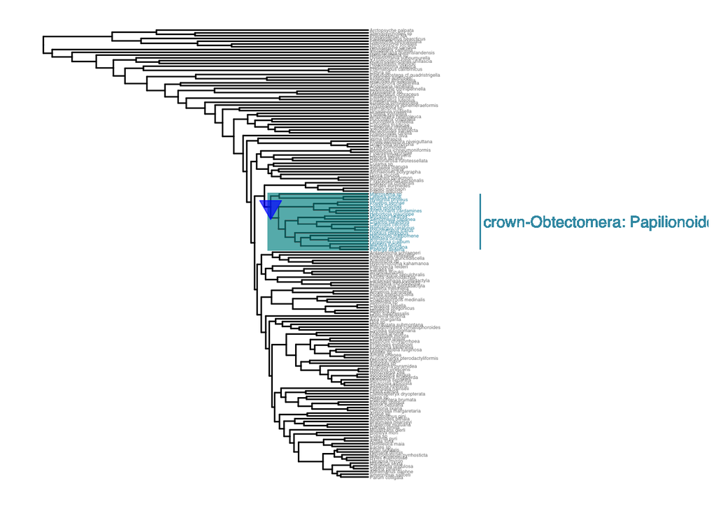

Figure 7: Visualization of evolutionary rate shift in the forewings’ PC2. Blue and downwards arrow indiactes a significant low rate shift. The table below shows the rate difference compared to the rest of the tree and the significance of the difference

```
## # A tibble: 1 × 4
##       n rate.difference p.value clade
##   <dbl>           <dbl>   <dbl> <chr>
## 1   263        -0.00163   0.001 crown-Obtectomera: Papilionoidea
```

#### Shape Evolution Correlation

##### Predictors of hindwing PC1

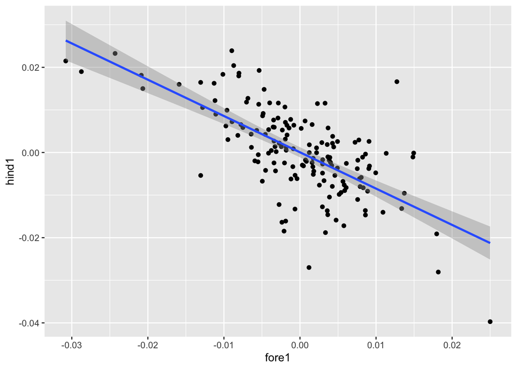

Figure 8: Linear regression plot of the dependent variable, hindwing PC1, against the independent variable, forewing PC1

```
##
## Call:
## lm(formula = hind1 ~ fore1, data = PC.pic)
##
## Residuals:
##        Min         1Q     Median         3Q        Max
## -0.0260404 -0.0039805 -0.0001178  0.0048720  0.0274366
##
## Coefficients:
##               Estimate Std. Error t value Pr(>|t|)
## (Intercept)  4.596e-05  6.011e-04   0.076    0.939
## fore1       -8.522e-01  7.445e-02 -11.447   <2e-16 ***
## ---
## Signif. codes:  0 '***' 0.001 '**' 0.01 '*' 0.05 '.' 0.1 ' ' 1
##
## Residual standard error: 0.007626 on 159 degrees of freedom
## Multiple R-squared:  0.4518, Adjusted R-squared:  0.4483
## F-statistic:   131 on 1 and 159 DF,  p-value: < 2.2e-16
```

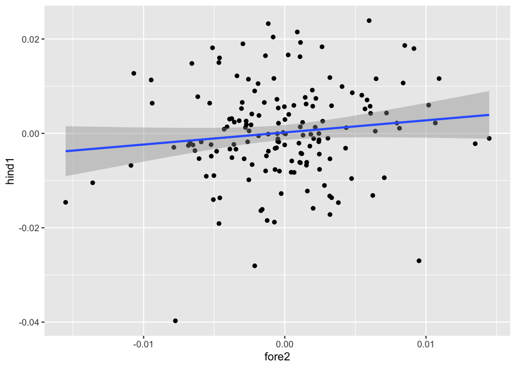

Figure 9: Linear regression plot of the dependent variable, hindwing PC1, against the independent variable, forewing PC2

Unlike that from Figure 8, the relationship between hindwing PC1 and forewing PC2 is not as clear and distinct.

```
##
## Call:
## lm(formula = hind1 ~ fore2, data = PC.pic)
##
## Residuals:
##       Min        1Q    Median        3Q       Max
## -0.037934 -0.005219 -0.000483  0.005633  0.023353
##
## Coefficients:
##              Estimate Std. Error t value Pr(>|t|)
## (Intercept) 0.0002032  0.0008060   0.252    0.801
## fore2       0.2564145  0.1662758   1.542    0.125
##
## Residual standard error: 0.01022 on 159 degrees of freedom
## Multiple R-squared:  0.01474,    Adjusted R-squared:  0.008539
## F-statistic: 2.378 on 1 and 159 DF,  p-value: 0.125
```

As expected from Figure 9, the correlation is weak and insignificant at any alpha level. An extremely large amount of variace in the hindwings’ PC1 is not explained as indicated by the low R-squared values.

```
##
## Call:
## lm(formula = hind1 ~ fore1 + fore2, data = PC.pic)
##
## Residuals:
##        Min         1Q     Median         3Q        Max
## -0.0279123 -0.0035558  0.0000419  0.0045677  0.0273003
##
## Coefficients:
##               Estimate Std. Error t value Pr(>|t|)
## (Intercept)  7.004e-05  5.986e-04   0.117    0.907
## fore1       -8.471e-01  7.419e-02 -11.418   <2e-16 ***
## fore2        1.937e-01  1.236e-01   1.568    0.119
## ---
## Signif. codes:  0 '***' 0.001 '**' 0.01 '*' 0.05 '.' 0.1 ' ' 1
##
## Residual standard error: 0.007591 on 158 degrees of freedom
## Multiple R-squared:  0.4602, Adjusted R-squared:  0.4533
## F-statistic: 67.34 on 2 and 158 DF,  p-value: < 2.2e-16
```

```
##
## Call:
## lm(formula = hind1 ~ fore1 * fore2, data = PC.pic)
##
## Residuals:
##       Min        1Q    Median        3Q       Max
## -0.028198 -0.003590 -0.000001  0.004534  0.026888
##
## Coefficients:
##               Estimate Std. Error t value Pr(>|t|)
## (Intercept)  0.0001173  0.0005965   0.197    0.844
## fore1       -0.8245486  0.0751805 -10.968   <2e-16 ***
## fore2        0.1851373  0.1231176   1.504    0.135
## fore1:fore2 26.1278715 16.4548677   1.588    0.114
## ---
## Signif. codes:  0 '***' 0.001 '**' 0.01 '*' 0.05 '.' 0.1 ' ' 1
##
## Residual standard error: 0.007555 on 157 degrees of freedom
## Multiple R-squared:  0.4687, Adjusted R-squared:  0.4586
## F-statistic: 46.17 on 3 and 157 DF,  p-value: < 2.2e-16
```

The two linear models above summarize the effects of PC1 and PC2 of the forewing on PC1 of the hindwing in a multivariate context. In both cases, forewing PC1 maintained its statistical significance and forewing PC2 maintained its insignificance. The low t-value of the interaction term also suggest that PC1 and PC2 of the forewing do not influence each others’ effects on hindwing PC1. Since there is also no significant change in the R-squared values from that in Figure 8, the linear model with only forewing PC1 would be the best and most straightforward predictor for hindwing PC1.

##### Predictors of hindwing PC2

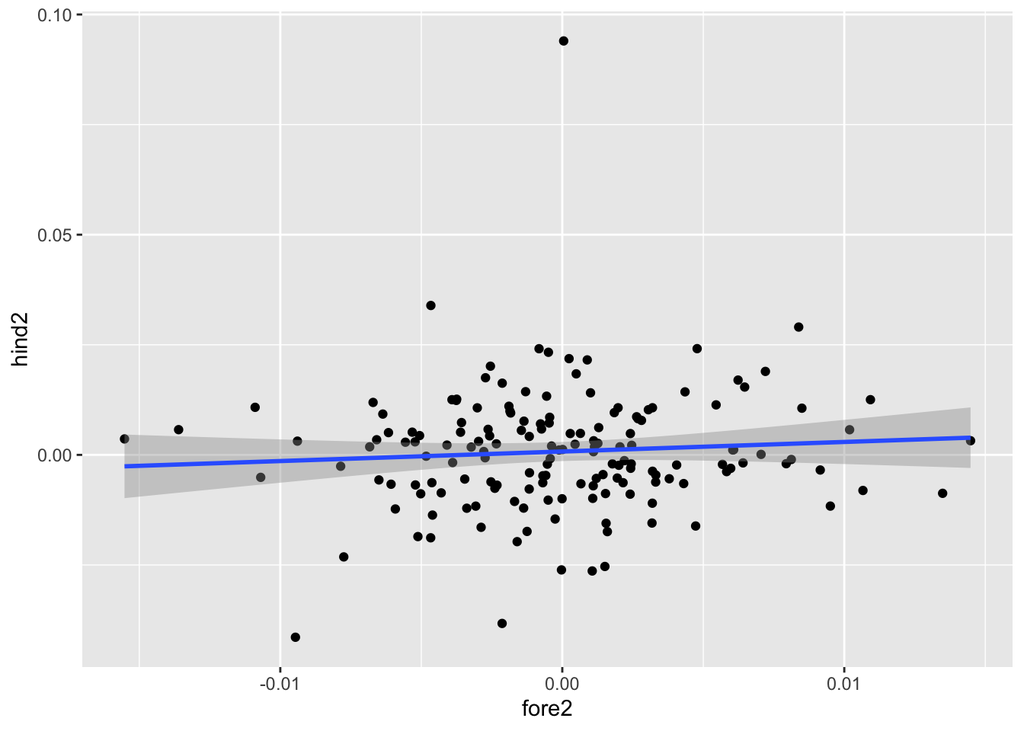

```
##
## Call:
## lm(formula = hind2 ~ fore2, data = PC.pic)
##
## Residuals:
##       Min        1Q    Median        3Q       Max
## -0.040124 -0.007141 -0.000287  0.007183  0.093217
##
## Coefficients:
##              Estimate Std. Error t value Pr(>|t|)
## (Intercept) 0.0007655  0.0010973   0.698    0.486
## fore2       0.2168695  0.2263817   0.958    0.340
##
## Residual standard error: 0.01392 on 159 degrees of freedom
## Multiple R-squared:  0.005739,   Adjusted R-squared:  -0.0005145
## F-statistic: 0.9177 on 1 and 159 DF,  p-value: 0.3395
```

```
##
## Call:
## lm(formula = hind2 ~ fore2 + fore1, data = PC.pic)
##
## Residuals:
##       Min        1Q    Median        3Q       Max
## -0.038352 -0.007732 -0.001232  0.007399  0.088731
##
## Coefficients:
##              Estimate Std. Error t value Pr(>|t|)
## (Intercept) 0.0008121  0.0010844   0.749   0.4550
## fore2       0.2388363  0.2238896   1.067   0.2877
## fore1       0.2969041  0.1343930   2.209   0.0286 *
## ---
## Signif. codes:  0 '***' 0.001 '**' 0.01 '*' 0.05 '.' 0.1 ' ' 1
##
## Residual standard error: 0.01375 on 158 degrees of freedom
## Multiple R-squared:  0.03553,    Adjusted R-squared:  0.02332
## F-statistic:  2.91 on 2 and 158 DF,  p-value: 0.05738
```

```
##
## Call:
## lm(formula = hind2 ~ fore2 * fore1, data = PC.pic)
##
## Residuals:
##       Min        1Q    Median        3Q       Max
## -0.037004 -0.007777 -0.000561  0.007578  0.089134
##
## Coefficients:
##               Estimate Std. Error t value Pr(>|t|)
## (Intercept)  7.649e-04  1.087e-03   0.704   0.4825
## fore2        2.474e-01  2.243e-01   1.103   0.2716
## fore1        2.744e-01  1.370e-01   2.004   0.0468 *
## fore2:fore1 -2.612e+01  2.998e+01  -0.871   0.3849
## ---
## Signif. codes:  0 '***' 0.001 '**' 0.01 '*' 0.05 '.' 0.1 ' ' 1
##
## Residual standard error: 0.01376 on 157 degrees of freedom
## Multiple R-squared:  0.04017,    Adjusted R-squared:  0.02183
## F-statistic:  2.19 on 3 and 157 DF,  p-value: 0.09135
```

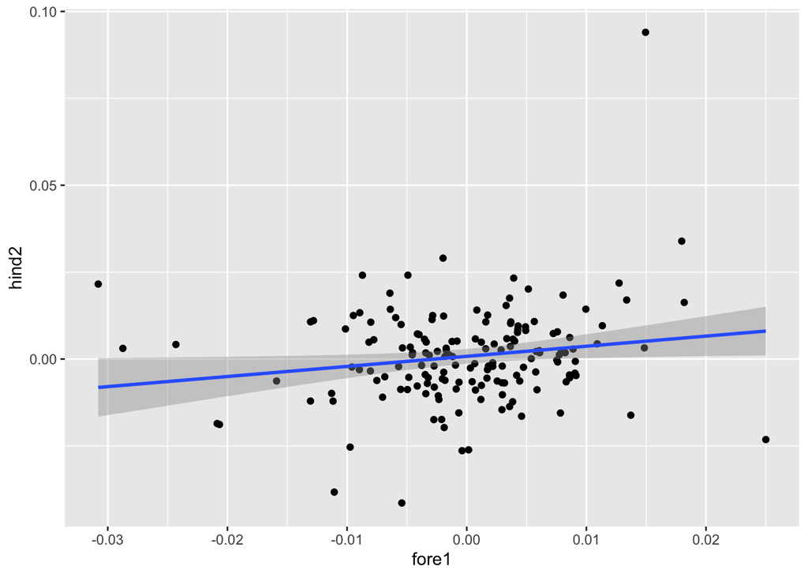

### Contributions

Jack: Methods + Intro + bib John: Intro + Results + bib Philip: Markdown File + Graphs + Code Samantha: Discussion